# Final Assignment pt 2

Derek Van Booven

2023-06-23

## Introduction

The specific question that I started with was was there a significant difference in the death per million rate between 2020 and 2021. Specifically I wanted to select the state of Florida since this has personal significance. To perform the analysis, I took the deaths from the COVID 19 download and calculated deaths per million. From this I compared the years of 2020 and 2021 to see perhaps if there was any difference between the two years.

To start with I downloaded the data from the Github repository that contained data from Johns Hopkins. Included in the data were 2 separate downloads, 1 consisted of cases, and the other was deaths. They included deaths by day so some manipulation needed to be done to transform the data into a usable datatable.

## Import the data

Import the data.

```r
url_in <- "https://raw.githubusercontent.com/CSSEGISandData/COVID-19/master/csse_covid_19_data/csse_covid_19_time_series/"

file_names <- c("time_series_covid19_deaths_US.csv", "time_series_covid19_confirmed_US.csv")
urls <- str_c(url_in, file_names)


us_cases <- read_csv(urls[2])
us_deaths <- read_csv(urls[1])
```

## Clean data

Using tidyverse I cleaned up the data by using the same methodology in the lecture. I used tidyverse to rename and reorganize the data with the intention of just keeping the data that I needed for final visualization and modeling.

```r
us_cases <- us_cases %>% pivot_longer(cols = -(UID:Combined_Key), names_to = "date", values_to = "cases") %>% select(Admin2:cases) %>%  mutate(dates = mdy(date)) %>% select(-c(Lat, Long_))

us_deaths <- us_deaths %>% pivot_longer(cols = -(UID:Population), names_to = "date", values_to = "deaths") %>% select(Admin2:deaths) %>% mutate(dates = mdy(date)) %>% select(-c(Lat, Long_))
```

## Additional Analysis

Included here I figured out a way to classify the dates into seasons. Originally, I wanted to seperate the data into seasons, but figured it was just as well that we could filter by date later if we needed to. However, I thought it was useful code that anyone could use.

```r
us_deaths <- us_deaths %>%
    mutate(mmdd = format(as.Date(date, "%Y-%m-%d"), "%m%d"),
           season = case_when(
               mmdd <= "0320" ~ "Winter",
               mmdd <= "0620" ~ "Spring",
               mmdd <= "0922" ~ "Summer",
               mmdd <= "1220" ~ "Autumn",
               TRUE ~ "Winter")) %>%
    select(-mmdd)

us_cases <- us_cases %>%
    mutate(mmdd = format(as.Date(date, "%Y-%m-%d"), "%m%d"),
           season = case_when(
               mmdd <= "0320" ~ "Winter",
               mmdd <= "0620" ~ "Spring",
               mmdd <= "0922" ~ "Summer",
               mmdd <= "1220" ~ "Autumn",
               TRUE ~ "Winter")) %>%
    select(-mmdd)

US <- us_cases %>% full_join(us_deaths)
```

[output not shown]

```r
US_permil <- US %>% mutate(deaths_per_mill = (deaths /Population) *  1000000)

florida_permil <- US_permil %>% filter(Province_State == "Florida")
```

## Visualizations

The graphs here will be by county to give a bit more granular look at the death rates.

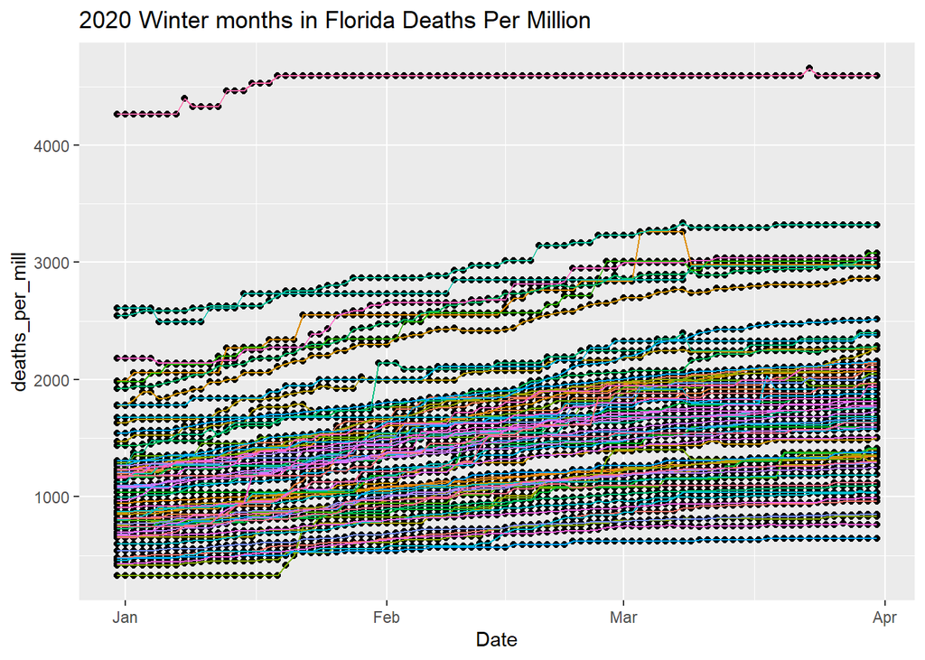

```r
florida2020 <- florida_permil %>% filter(between(dates, as.Date('2020-12-31'), as.Date('2021-03-31')))

florida2021 <- florida_permil %>% filter(between(dates, as.Date('2021-12-31'), as.Date('2022-03-31')))

ggplot(florida2020, aes(x = dates, y = deaths_per_mill, group = Admin2)) + geom_point() + geom_line(aes(color = Admin2), show.legend = FALSE) + ggtitle("2020 Winter months in Florida Deaths Per Million") + xlab("Date")
```

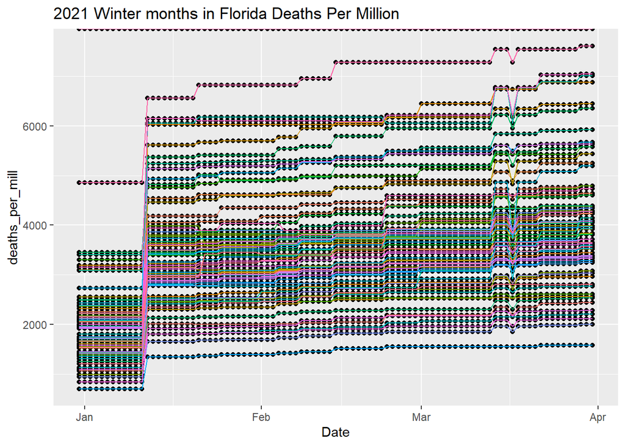

```r
ggplot(florida2021, aes(x = dates, y = deaths_per_mill, group = Admin2)) + geom_point() + geom_line(aes(color = Admin2), show.legend = FALSE) + ggtitle("2021 Winter months in Florida Deaths Per Million") + xlab("Date")
```

## Impressions

Second, the graph in 2020 shows relatively low numbers for most of the counties. There is a single county (Miami/Dade) where the death rate was exceptionally high. Most of the counties were lower. Switch over to 2021 and you can see a more broad spectrum in regards to the death rate.

## Modeling

Here I wanted to see if there was a relationship between cases and deaths from within Florida for 2020.

```r
lm.model20 = lm(deaths ~ cases, florida2020)
summary(lm.model20)
```

```
##
## Call:
## lm(formula = deaths ~ cases, data = florida2020)
##
## Residuals:
##     Min      1Q  Median      3Q     Max
## -529.00  -66.85  -50.38   43.55  837.10
##
## Coefficients:
##              Estimate Std. Error t value Pr(>|t|)
## (Intercept) 6.685e+01  2.269e+00   29.46   <2e-16 ***
## cases       1.333e-02  3.774e-05  353.08   <2e-16 ***
## ---
## Signif. codes:  0 '***' 0.001 '**' 0.01 '*' 0.05 '.' 0.1 ' ' 1
##
## Residual standard error: 162.4 on 6277 degrees of freedom
## Multiple R-squared:  0.9521, Adjusted R-squared:  0.9521
## F-statistic: 1.247e+05 on 1 and 6277 DF,  p-value: < 2.2e-16
```

```r
lm.model21 = lm(deaths ~ cases, florida2021)
summary(lm.model21)
```

```
##
## Call:
## lm(formula = deaths ~ cases, data = florida2021)
##
## Residuals:
##     Min      1Q  Median      3Q     Max
## -3089.8  -243.5  -195.4    86.2 25420.8
##
## Coefficients:
##              Estimate Std. Error t value Pr(>|t|)
## (Intercept) 2.678e+02  1.617e+01   16.56   <2e-16 ***
## cases       8.935e-03  8.961e-05   99.70   <2e-16 ***
## ---
## Signif. codes:  0 '***' 0.001 '**' 0.01 '*' 0.05 '.' 0.1 ' ' 1
##
## Residual standard error: 1149 on 6277 degrees of freedom
## Multiple R-squared:  0.613,  Adjusted R-squared:  0.6129
## F-statistic:  9941 on 1 and 6277 DF,  p-value: < 2.2e-16
```

Here we can see that there is a fairly strong relationship between cases and deaths, and the F/T statistics are showing promising p-values. Interestingly, the r squared value for 2020 is much higher than 2021. This needs a little further investigation so let’s do a simple correlation analysis.

## Correlation Analysis

To look at the results of the regression model a little closer, I wanted to do a correlation analysis between cases and deaths from 2020 and 2021. To do this it’s a simple cor function and using the corrplot you can visually see the results.

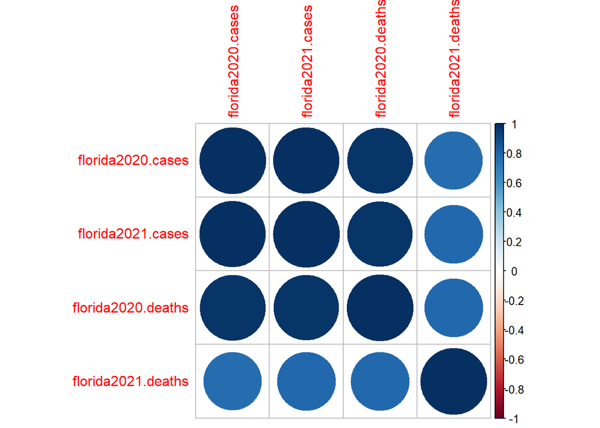

```r
for_correlation <- data.frame(florida2020$cases, florida2021$cases, florida2020$deaths, florida2021$deaths)
corrplot(cor(for_correlation))
```

Here you can clearly see there is a correlation between 2020 cases/deaths and 2021 cases. However, there appears to be a bit of a lesser correlation between 2021 deaths and cases. In fact the 2021 Florida deaths have a lower correlation on everything it appears. This would be interesting to investigate further.